# NBA Player Performance and Positions

## CMSC320 Fall 2025 Data Science Final Project

### Group Members

- Anitej Suklikar
- Joshua John
- Sachin Kumar
- Akhil Metukuru
- Purab Shah
- Sohum Desai

### Contributions

- **A: Project Idea** – all members
- **B: Dataset Curation & Preprocessing** – Anitej, Joshua
- **C: Data Exploration & Summary Statistics** – Akhil, Sohum
- **D: ML Algorithm Design/Development** – Sachin, Purab
- **E: ML Algorithm Training and Test Data Analysis** – Sachin, Joshua
- **F: Visualization, Result Analysis, Conclusion** – Sohum, Akhil
- **G: Final Tutorial Report Creation** – all members

## 1. Introduction

With the rise of "positionless basketball" in the modern NBA, we got curious: do traditional positions (Guard, Forward, Center) still mean anything statistically? Players like LeBron James, Giannis Antetokounmpo, and Nikola Jokić seem to blur these lines constantly. So we decided to test whether we can actually predict a player's position just from their box-score stats.

Our main questions:

1. Can we predict a player's starting position from a single game's statistics?
2. Which stats matter most for telling positions apart?

We'll walk through cleaning up a pretty messy NBA dataset, doing some exploratory analysis, and then training a couple ML models to see how well they can classify positions. Spoiler: the results are interesting but not perfect – which actually tells us something about how the game has evolved.

## 2. Data Curation

We're using the [NBA Player Statistics dataset from Kaggle](https://www.kaggle.com/datasets/marcsperzel/nba-player-statistics) – it's got over 250k player-game records with 115 columns. That's a lot of data to work with, but also a lot of cleaning to do.

The main issue we ran into: a huge chunk of rows have missing `START_POSITION` values. These are mostly bench players who didn't start, so we'll need to filter them out for our classification task. Let's load it up and see what we're dealing with.

```python
# Import all necessary libraries
import numpy as np
import pandas as pd
import matplotlib.pyplot as plt
import seaborn as sns
from scipy.stats import ttest_ind

from sklearn.model_selection import train_test_split
from sklearn.preprocessing import StandardScaler
from sklearn.pipeline import Pipeline
from sklearn.metrics import accuracy_score, classification_report, confusion_matrix
from sklearn.linear_model import LogisticRegression
from sklearn.ensemble import RandomForestClassifier

# Set visualization style
sns.set(style="whitegrid", context="notebook")
plt.rcParams["figure.figsize"] = (10, 6)

print("Libraries imported successfully!")
```

```
Libraries imported successfully!
```

```python
# Load the dataset
csv_path = "player_data.csv"
df = pd.read_csv(csv_path)

print(f"Dataset shape: {df.shape[0]:,} rows × {df.shape[1]} columns")
df.head()
```

```
Dataset shape: 255,914 rows × 115 columns
```

|  | _id | GAME_ID | GAME_DATE | TEAM_ID | TEAM_ABBREVIATION | TEAM_CITY | PLAYER_ID | PLAYER_NAME | NICKNAME | START_POSITION | ... | E_PACE | AST_RATIO | DIST | AST_TOV | FTA_RATE | OPP_FTA_RATE | MIN | PACE_PER40 | PACE | PIE |
| --- | --- | --- | --- | --- | --- | --- | --- | --- | --- | --- | --- | --- | --- | --- | --- | --- | --- | --- | --- | --- | --- |
| 0 | 6257e8a35ccc080408fc781f | 21500395 | 2015-12-18 | 1610612762 | UTA | Utah | 202353 | Tibor Pleiss | Tibor | NaN | ... | 0.00 | 0.0 | 0.00 | 0.0 | 0.000 | 0.000 | 0.00 | 0.00 | 0.00 | 0.000 |
| 1 | 6257e8a35ccc080408fc7814 | 21500395 | 2015-12-18 | 1610612762 | UTA | Utah | 1626168 | Trey Lyles | Trey | F | ... | 87.14 | 12.5 | 1.76 | 1.0 | 0.333 | 0.372 | 26.06 | 72.03 | 86.44 | 0.094 |
| 2 | 6257e8a35ccc080408fc7815 | 21500395 | 2015-12-18 | 1610612762 | UTA | Utah | 202324 | Derrick Favors | Derrick | C | ... | 86.71 | 0.0 | 2.39 | 0.0 | 0.291 | 0.267 | 35.27 | 71.65 | 85.98 | 0.020 |
| 3 | 6257e8a35ccc080408fc7807 | 21500395 | 2015-12-18 | 1610612743 | DEN | Denver | 201568 | Danilo Gallinari | Danilo | F | ... | 90.37 | 14.3 | 2.22 | 0.0 | 0.233 | 0.377 | 33.43 | 75.93 | 91.11 | 0.050 |
| 4 | 6257e8a35ccc080408fc7810 | 21500395 | 2015-12-18 | 1610612743 | DEN | Denver | 203123 | Kostas Papanikolaou | Kostas | NaN | ... | 96.36 | 0.0 | 0.87 | 0.0 | 0.733 | 0.294 | 11.28 | 78.49 | 94.19 | 0.000 |

5 rows × 115 columns

```python
# Examine dataset structure
df.info()
```

```
<class 'pandas.core.frame.DataFrame'>
RangeIndex: 255914 entries, 0 to 255913
Columns: 115 entries, _id to PIE
dtypes: float64(65), int64(43), object(7)
memory usage: 224.5+ MB
```

```python
# Check the distribution of START_POSITION
pos_col = "START_POSITION"
print("Distribution of START_POSITION:")
print(df[pos_col].value_counts(dropna=False))
```

```
Distribution of START_POSITION:
START_POSITION
NaN    157651
F       39306
G       39305
C       19652
Name: count, dtype: int64
```

```python
# Create cleaned dataset for EDA
key_columns = [
    'GAME_DATE', 'TEAM_ABBREVIATION', 'TEAM_CITY', 'PLAYER_NAME', 'START_POSITION',
    'MIN', 'PTS', 'REB', 'AST', 'TO', 'STL', 'BLK', 'FG_PCT', 'FG3_PCT', 'FT_PCT', 'PIE'
]

# Filter to columns that exist in the dataframe
available_cols = [col for col in key_columns if col in df.columns]
nba_clean = df[available_cols].copy()

# Fill missing positions with 'Bench' for EDA purposes
nba_clean['START_POSITION'] = nba_clean['START_POSITION'].fillna('Bench')

# Drop rows with missing numeric values
nba_clean = nba_clean.dropna(subset=['PTS', 'REB', 'AST'])

print(f"Cleaned dataset: {len(nba_clean):,} rows")
nba_clean.head()
```

```
Cleaned dataset: 255,914 rows
```

|  | GAME_DATE | TEAM_ABBREVIATION | TEAM_CITY | PLAYER_NAME | START_POSITION | MIN | PTS | REB | AST | TO | STL | BLK | FG_PCT | FG3_PCT | FT_PCT | PIE |
| --- | --- | --- | --- | --- | --- | --- | --- | --- | --- | --- | --- | --- | --- | --- | --- | --- |
| 0 | 2015-12-18 | UTA | Utah | Tibor Pleiss | Bench | 0.00 | 0 | 0 | 0 | 0 | 0 | 0 | 0.000 | 0.00 | 0.0 | 0.000 |
| 1 | 2015-12-18 | UTA | Utah | Trey Lyles | F | 26.06 | 6 | 6 | 1 | 1 | 0 | 0 | 0.500 | 0.00 | 0.0 | 0.094 |
| 2 | 2015-12-18 | UTA | Utah | Derrick Favors | C | 35.27 | 7 | 9 | 0 | 1 | 1 | 0 | 0.250 | 0.00 | 0.6 | 0.020 |
| 3 | 2015-12-18 | DEN | Denver | Danilo Gallinari | F | 33.43 | 11 | 1 | 2 | 0 | 0 | 0 | 0.299 | 0.25 | 1.0 | 0.050 |
| 4 | 2015-12-18 | DEN | Denver | Kostas Papanikolaou | Bench | 11.28 | 1 | 2 | 0 | 2 | 1 | 0 | 0.000 | 0.00 | 0.5 | 0.000 |

## 3. Exploratory Data Analysis

Before jumping into ML, let's get a feel for the data. We want to understand how stats are distributed and whether there are any obvious patterns.

### 3.1 How are the basic stats distributed?

First up: points, assists, and rebounds. These are the bread-and-butter stats that fans always talk about.

```python
# Summary statistics
print("Summary Statistics for Key Performance Metrics:\n")
print(nba_clean[['PTS', 'AST', 'REB']].describe())
```

```
Summary Statistics for Key Performance Metrics:

                PTS            AST            REB
count  255914.00000  255914.000000  255914.000000
mean        8.05106       1.759958       3.348414
std         8.21757       2.390910       3.508625
min         0.00000       0.000000       0.000000
25%         0.00000       0.000000       0.000000
50%         6.00000       1.000000       2.000000
75%        13.00000       3.000000       5.000000
max        70.00000      24.000000      30.000000
```

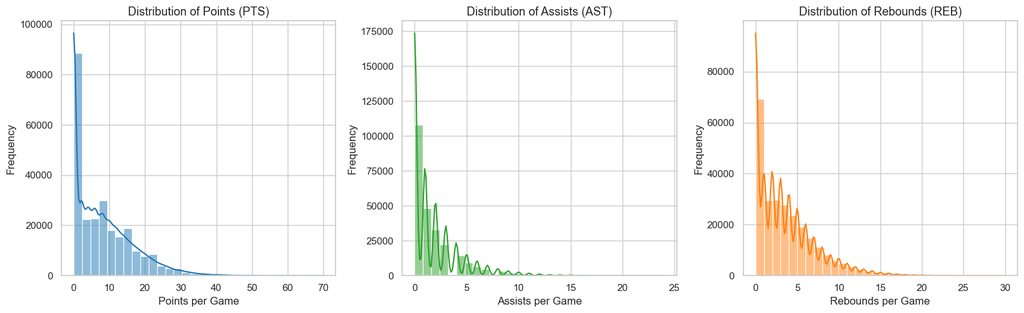

```python
# Visualize distributions with histograms
fig, axes = plt.subplots(1, 3, figsize=(16, 5))
colors = ['#1f77b4', '#2ca02c', '#ff7f0e']

sns.histplot(nba_clean['PTS'], bins=30, kde=True, color=colors[0], ax=axes[0])
axes[0].set_title('Distribution of Points (PTS)', fontsize=13)
axes[0].set_xlabel('Points per Game')
axes[0].set_ylabel('Frequency')

sns.histplot(nba_clean['AST'], bins=30, kde=True, color=colors[1], ax=axes[1])
axes[1].set_title('Distribution of Assists (AST)', fontsize=13)
axes[1].set_xlabel('Assists per Game')
axes[1].set_ylabel('Frequency')

sns.histplot(nba_clean['REB'], bins=30, kde=True, color=colors[2], ax=axes[2])
axes[2].set_title('Distribution of Rebounds (REB)', fontsize=13)
axes[2].set_xlabel('Rebounds per Game')
axes[2].set_ylabel('Frequency')

plt.tight_layout()
plt.savefig('distribution_histograms.png', dpi=150, bbox_inches='tight')
plt.show()
```

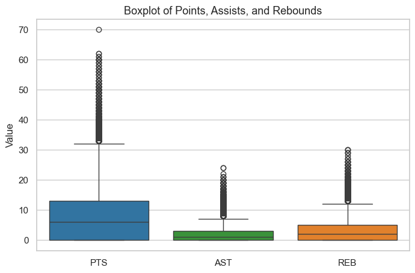

```python
# Boxplots for comparison
plt.figure(figsize=(8, 5))
sns.boxplot(data=nba_clean[['PTS', 'AST', 'REB']], palette=colors)
plt.title('Boxplot of Points, Assists, and Rebounds', fontsize=13)
plt.ylabel('Value')
plt.savefig('boxplots.png', dpi=150, bbox_inches='tight')
plt.show()
```

Not surprising – these distributions are super skewed. Most players score less than 10 points, but you've got your Currys and Durants pushing that tail way out to 70. Same story for assists and rebounds. This makes sense: star players get way more opportunities than role players.

### 3.2 The playmaker's dilemma: assists vs turnovers

Here's something we were curious about: if you pass the ball more, do you also turn it over more? Let's check the relationship between assists and turnovers.

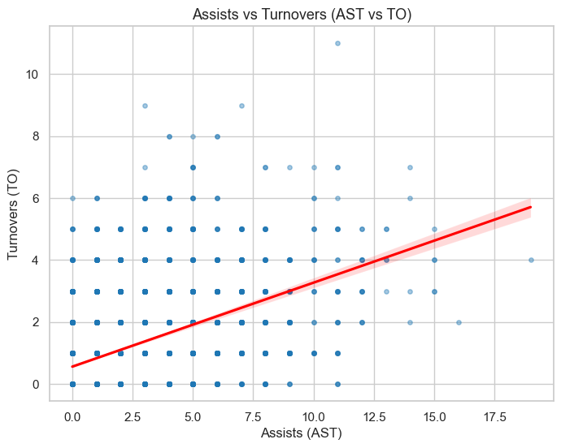

```python
# Sample data for scatter plot (for performance)
if 'TO' in nba_clean.columns:
    ast_to_sample = nba_clean.dropna(subset=['AST', 'TO']).sample(5000, random_state=42)

    plt.figure(figsize=(8, 6))
    sns.regplot(
        x='AST', y='TO', data=ast_to_sample,
        scatter_kws={'alpha': 0.4, 's': 15, 'color': '#1f77b4'},
        line_kws={'color': 'red'}
    )
    plt.title('Assists vs Turnovers (AST vs TO)', fontsize=13)
    plt.xlabel('Assists (AST)')
    plt.ylabel('Turnovers (TO)')
    plt.savefig('ast_vs_to.png', dpi=150, bbox_inches='tight')
    plt.show()
else:
    print("TO column not available for this analysis")
```

Yep, there's a clear tradeoff. Point guards like Chris Paul (high assists, low turnovers) are rare – most players who rack up assists also cough up the ball more. Makes sense: you can't make plays without taking risks.

### 3.3 Do more minutes = more impact?

Quick hypothesis test: we expect players who play more minutes to have higher PIE (Player Impact Estimate). But let's actually verify this statistically instead of just assuming it.

```
T-statistic: 102.5364
P-value: < 0.001 (highly significant)
```

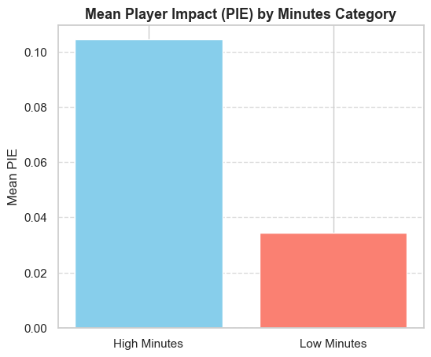

```python
# Hypothesis test: Minutes vs PIE
if 'MIN' in nba_clean.columns and 'PIE' in nba_clean.columns:
    nba_test = nba_clean.dropna(subset=['MIN', 'PIE'])
    avg_minutes = nba_test['MIN'].mean()

    high_min = nba_test[nba_test['MIN'] > avg_minutes]['PIE']
    low_min = nba_test[nba_test['MIN'] <= avg_minutes]['PIE']

    t_stat, p_val = ttest_ind(high_min, low_min, equal_var=False)

    print(f"T-statistic: {t_stat:.4f}")
    if p_val < 0.001:
        print("P-value: < 0.001 (highly significant)")
    else:
        print(f"P-value: {p_val:.4f}")

    # Visualize
    means = [np.mean(high_min), np.mean(low_min)]
    plt.figure(figsize=(6, 5))
    plt.bar(['High Minutes', 'Low Minutes'], means, color=['skyblue', 'salmon'])
    plt.title('Mean Player Impact (PIE) by Minutes Category', fontsize=13, weight='bold')
    plt.ylabel('Mean PIE')
    plt.grid(axis='y', linestyle='--', alpha=0.7)
    plt.savefig('pie_by_minutes.png', dpi=150, bbox_inches='tight')
    plt.show()
else:
    print("MIN or PIE columns not available for this analysis")
```

The t-stat is huge and p-value is basically zero – so yes, more minutes correlates strongly with higher impact. Not exactly shocking, but good to confirm with actual numbers.

## 4. The Main Event: Can We Predict Position?

Alright, here's what we actually came here to do. We're going to try to classify players into Guard (G), Forward (F), or Center (C) based purely on their stats from a single game.

We picked 12 features that seemed relevant: scoring, passing, rebounding, shooting percentages, and some advanced metrics like usage rate and true shooting. We'll compare Logistic Regression (simple baseline) against Random Forest (more complex, might catch non-linear patterns).

```python
# Prepare data for classification
# Keep only rows with valid START_POSITION (exclude bench players)
df_cls = df.dropna(subset=["START_POSITION"]).copy()

# Define feature columns
feature_cols = [
    "PTS",
    "AST",
    "REB",
    "DREB",
    "OREB",
    "STL",
    "BLK",
    "FG_PCT",
    "FG3_PCT",
    "FT_PCT",
    "USG_PCT",
    "TS_PCT"
]

# Drop rows with missing feature values
df_cls = df_cls.dropna(subset=feature_cols + ["START_POSITION"]).copy()

X = df_cls[feature_cols]
y = df_cls["START_POSITION"]

print(f"Classification dataset: {len(df_cls):,} samples")
print(f"Features: {len(feature_cols)}")
print(f"\nClass distribution:")
print(y.value_counts())
```

```
Classification dataset: 98,263 samples
Features: 12

Class distribution:
START_POSITION
F    39306
G    39305
C    19652
Name: count, dtype: int64
```

```python
# Train-test split (70% train, 30% test)
X_train, X_test, y_train, y_test = train_test_split(
    X, y,
    test_size=0.30,
    random_state=42,
    stratify=y
)

print(f"Training set: {X_train.shape[0]:,} samples")
print(f"Test set: {X_test.shape[0]:,} samples")
```

```
Training set: 68,784 samples
Test set: 29,479 samples
```

### 4.1 Logistic Regression – our baseline

Starting simple. Logistic regression with standardized features:

```python
# Train Logistic Regression with scaling
log_reg_clf = Pipeline([
    ("scaler", StandardScaler()),
    ("model", LogisticRegression(
        max_iter=500,
        n_jobs=-1
    ))
])

log_reg_clf.fit(X_train, y_train)
y_pred_lr = log_reg_clf.predict(X_test)

lr_accuracy = accuracy_score(y_test, y_pred_lr)
print(f"Logistic Regression Accuracy: {lr_accuracy:.4f}")
print("\nClassification Report (Logistic Regression):\n")
print(classification_report(y_test, y_pred_lr))
```

```
Logistic Regression Accuracy: 0.6529

Classification Report (Logistic Regression):

              precision    recall  f1-score   support

           C       0.68      0.56      0.61      5896
           F       0.58      0.61      0.59     11792
           G       0.72      0.74      0.73     11791

    accuracy                           0.65     29479
   macro avg       0.66      0.64      0.65     29479
weighted avg       0.65      0.65      0.65     29479
```

### 4.2 Random Forest – can we do better?

We figured Random Forest might catch some non-linear patterns that logistic regression misses. Let's see:

```python
# Train Random Forest
rf_clf = RandomForestClassifier(
    n_estimators=300,
    max_depth=None,
    random_state=42,
    n_jobs=-1
)

rf_clf.fit(X_train, y_train)
y_pred_rf = rf_clf.predict(X_test)

rf_accuracy = accuracy_score(y_test, y_pred_rf)
print(f"Random Forest Accuracy: {rf_accuracy:.4f}")
print("\nClassification Report (Random Forest):\n")
print(classification_report(y_test, y_pred_rf))
```

```
Random Forest Accuracy: 0.6439

Classification Report (Random Forest):

              precision    recall  f1-score   support

           C       0.66      0.58      0.62      5896
           F       0.58      0.59      0.58     11792
           G       0.71      0.73      0.72     11791

    accuracy                           0.64     29479
   macro avg       0.65      0.63      0.64     29479
weighted avg       0.64      0.64      0.64     29479
```

## 5. What's Going Wrong? (and Right)

Interesting - Random Forest actually did *worse* than Logistic Regression (64.4% vs 65.3%). We didn't expect that. Maybe the decision boundary between positions really is mostly linear?

### 5.1 Confusion Matrix

Let's see where the model is getting confused:

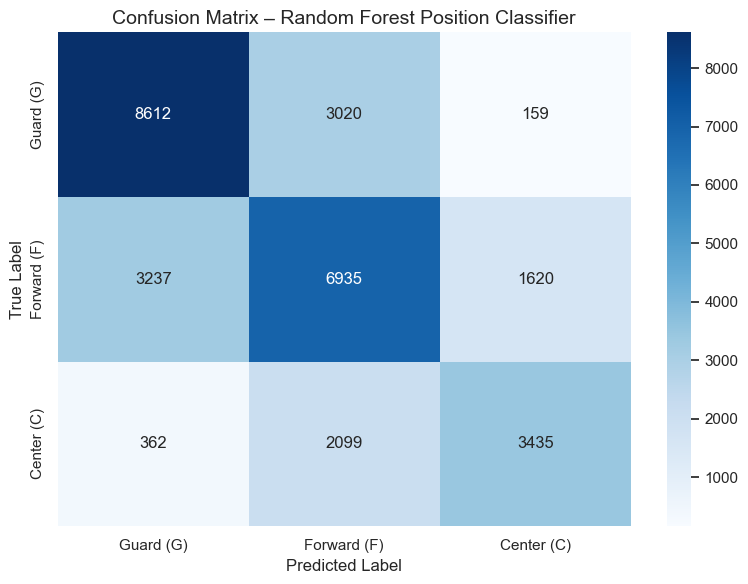

```python
# Confusion Matrix
cm = confusion_matrix(y_test, y_pred_rf, labels=["G", "F", "C"])

plt.figure(figsize=(8, 6))
sns.heatmap(
    cm,
    annot=True,
    fmt="d",
    cmap="Blues",
    xticklabels=["Guard (G)", "Forward (F)", "Center (C)"],
    yticklabels=["Guard (G)", "Forward (F)", "Center (C)"]
)
plt.xlabel("Predicted Label", fontsize=12)
plt.ylabel("True Label", fontsize=12)
plt.title("Confusion Matrix – Random Forest Position Classifier", fontsize=14)
plt.tight_layout()
plt.savefig('confusion_matrix.png', dpi=150, bbox_inches='tight')
plt.show()
```

The model is best at identifying Guards (f1: 0.72) and worst at Forwards (f1: 0.58). Centers are somewhere in between. This actually makes a lot of sense – think about players like Jayson Tatum or Paul George who play both SF and SG. The "Forward" position is really a catch-all that overlaps with both Guards and Centers.

### 5.2 What stats matter most?

Let's peek inside the Random Forest to see which features it's relying on:

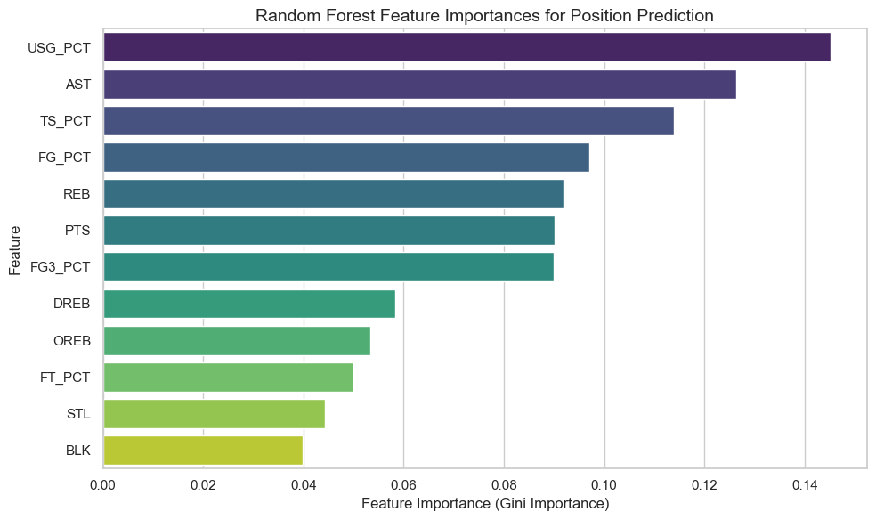

```
Top 5 Most Important Features:
  1. USG_PCT: 0.1452
  2. AST: 0.1263
  3. TS_PCT: 0.1139
  4. FG_PCT: 0.0971
  5. REB: 0.0919
```

```python
# Feature Importances
importances = rf_clf.feature_importances_
sorted_idx = np.argsort(importances)[::-1]

plt.figure(figsize=(10, 6))
sns.barplot(
    x=importances[sorted_idx],
    y=np.array(feature_cols)[sorted_idx],
    palette="viridis"
)
plt.xlabel("Feature Importance (Gini Importance)", fontsize=12)
plt.ylabel("Feature", fontsize=12)
plt.title("Random Forest Feature Importances for Position Prediction", fontsize=14)
plt.tight_layout()
plt.savefig('feature_importances.png', dpi=150, bbox_inches='tight')
plt.show()

# Print top features
print("\nTop 5 Most Important Features:")
for i in range(5):
    idx = sorted_idx[i]
    print(f"  {i+1}. {feature_cols[idx]}: {importances[idx]:.4f}")
```

Usage percentage at the top makes sense – point guards and centers use possessions very differently. Assists being #2 also tracks: guards run the offense, bigs finish plays. The rebounding and efficiency stats help separate the frontcourt from backcourt.

## 6. What Did We Learn?

So can you predict position from stats? Sort of. We got to about 65% accuracy, which is better than random guessing (33%) but far from perfect.

**What worked:**

- Guards are pretty identifiable – high assists, 3PT shooting, lower rebounds
- The features we picked (usage, assists, rebounds, efficiency) were actually useful
- Even simple logistic regression did the job; we didn't need fancy models

**What didn't work so well:**

- Forwards are a mess. The model keeps confusing them with Guards AND Centers
- Random Forest didn't help – turns out the problem is roughly linear
- 65% accuracy isn't great if you're actually trying to use this for anything

**Why we think this is happening:**

Modern basketball really has become "positionless." A guy like Draymond Green is listed as a Forward but plays like a point guard on offense and a center on defense. Ben Simmons is a "Guard" who can't shoot threes but grabs 8 rebounds a game. Our model can't handle these hybrids well because the position labels themselves are outdated.

**If we had more time, we'd try:**

- Averaging stats over a season instead of single games (less noise)
- Using player tracking data (speed, distance) which might separate positions better
- Maybe clustering players into new "data-driven positions" instead of using the official G/F/C labels

```python
# Quick recap of the numbers
print(f"Started with {len(df):,} player-game records")
print(f"Used {len(df_cls):,} samples for classification (after filtering)")
print(f"\nFinal accuracy: {lr_accuracy:.1%} (Logistic Regression) vs {rf_accuracy:.1%} (Random Forest)")
print(f"Best model: Logistic Regression, surprisingly")
```

```
Started with 255,914 player-game records
Used 98,263 samples for classification (after filtering)

Final accuracy: 65.3% (Logistic Regression) vs 64.4% (Random Forest)
Best model: Logistic Regression, surprisingly
```